# Introduction

We are a given a sales history from a E-commerce website. It lists all transactions from 12/01/2010 to 12/09/2011.

This study is about predicting future trends (forecasting) using neural networks (LSTMs).

## Library loading

```python
from sklearn.preprocessing import MinMaxScaler
from keras.layers import LSTM, Dropout, Dense
from keras.models import Sequential
import matplotlib.pyplot as plt
import numpy as np
import pandas as pd
from Classes_and_functions import create_transactions_list
```

## Data loading

```python
### Load the data
data = pd.read_csv("data.csv",sep=",",encoding="latin")
```

## Data preprocessing

```python
### Remove na values
data = data.dropna()
```

```python
### Display feature names
print([col for col in data.columns])
```

```
['InvoiceNo', 'StockCode', 'Description', 'Quantity', 'InvoiceDate', 'UnitPrice', 'CustomerID', 'Country']
```

## Transaction objects instantiating

```python
### We iterate through the dataframe to create transaction objects
Transactions,time = create_transactions_list(data)
```

```
Transactions list creation monitoring: 2,38.44  seconds
```

```python
### We remove cancelled transactions as there are not useful
raw_sales = [i.get_total_price() for i in Transactions ]
cancelled = [i.get_stockcode() for i in Transactions if i.is_cancelled() is True]
sales = [i.get_total_price() for i in Transactions if i.get_stockcode() not in cancelled]
dates = [i.get_date() for i in Transactions if i.get_stockcode() not in cancelled]
```

## Timepoints saving

```python
### And add timepoints for interesting periods
backtoschool = [1 if i.get_date()[0:1]=="9" else 0 for i in Transactions
               if i.get_stockcode() not in cancelled]
christmas = [1 if i.get_date()[0:2]=="12" else 0 for i in Transactions
               if i.get_stockcode() not in cancelled]
```

## Data visualization

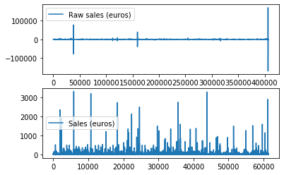

```python
### Short Datavisualization to check
plt.subplot(211)
plt.plot(raw_sales,label="Raw sales (euros)")
plt.legend()
plt.subplot(212)
plt.plot(sales,label="Sales (euros)")
plt.legend()
plt.show()
```

## Binning

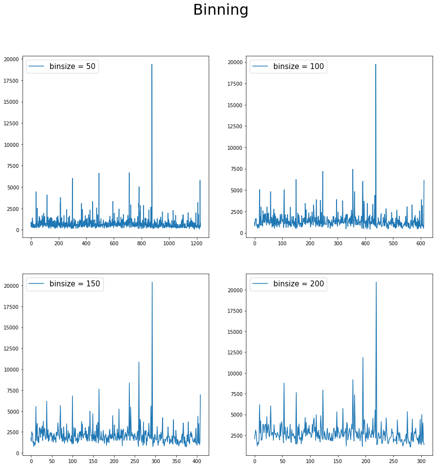

```python
#plt.plot([np.log(i+1) for i in sales])
#plt.show()
def binning(list,bw):
    return [sum(list[i:i+bw]) for i in range(0,len(list)-bw,bw)]

f = plt.figure(figsize=(15,15))
f.suptitle("Binning",fontsize=30)
ax = f.add_subplot(221)
ax.plot(binning(sales,50),label="binsize = 50")
ax.legend(fontsize=15)
ax2 = f.add_subplot(222)
ax2.plot(binning(sales,100),label="binsize = 100")
ax2.legend(fontsize=15)
ax3 = f.add_subplot(223)
ax3.plot(binning(sales,150),label="binsize = 150")
ax3.legend(fontsize=15)
ax4 = f.add_subplot(224)
ax4.plot(binning(sales,200),label="binsize = 200")
ax4.legend(fontsize=15)
```

## Moving average

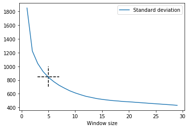

```python
def moving_average(list,size):
    return [np.mean(list[i:i+size]) for i in range(len(list)-size)]

binned = binning(sales,250)
stds_wins = [(np.std(moving_average(binned,size)),size)
             for size in range(30)]

plt.plot([i[1] for i in stds_wins],[i[0] for i in stds_wins],
         label="Standard deviation")
plt.hlines(y=850,xmin=3,xmax=7,linestyle="--")
plt.vlines(x=5,ymin=700,ymax=1000,linestyle="--")
plt.xlabel('Window size')
plt.legend()
plt.show()
```

Choosing a window size of 5 allows us to keep enough variability without oversmoothing the time serie.

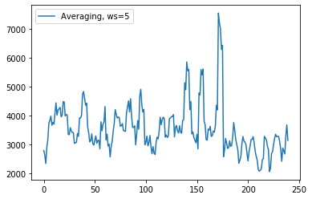

```python
ma_5 = moving_average(binned,5)
plt.plot(ma_5,label="Averaging, ws=5")
plt.legend()
plt.show()
```

Averaging using the previously determined window size results in enough variability and improved stationarity. As we can see, a low sales period appears after the huge peak.

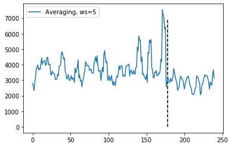

```python
plt.plot(ma_5,label="Averaging, ws=5")
plt.vlines(x=178,ymin=0,ymax=7000,linestyle="--")
plt.legend()
plt.show()
```

We will use the data before this timepoint to train our predictor, the remaining will be used to evaluate the model.

In other words, we will challenge the model to predict that "low sales" period.

## The LSTM model

LSTM models inputs has not the same shape than those used in non recurrent neural networks. They take N dimensional vectors as inputs to predict next values. Data are like the scenes of a film. The more we go through the film the best we can predict the end. Good scenarii are less predictable than others. Approching the end of the film, most of us are absorbed by the current scene, forgetting the begining of the film. Cinephiles will take account of the way the author orchestrate each scene, until then end. In that way, good cinephiles are able to predict the end of the film before its end.

Good models are good cinephiles. In the same way, data that are hard to handle are very good films. After having averaged our "scenes", we will try to find a cinephile that is able predict the end of the film with very low error.

```python
## We split the data in training and test sets
X_train = [[i] for i in ma_5[:178]]
X_test = [[i] for i in ma_5[178:]]
```

```python
## And scale the data
scaler = MinMaxScaler(feature_range = (0, 1))
scaled = scaler.fit_transform(X_train)
scaled_test = scaler.fit_transform(X_test)
```

### Data formatting

Here, we define a delay at the end of which the cinephile will say to itself "Okay this scene is getting obvious, this actor will surely die after this". The smaller the delay, the more the cinephile will catch information (risking to pay attention to unsignificant things). But choosing a too long delay will also increase the risk to not pay attention to important features such as recurring actions that will presuppose the end of the film.

```python
## We define a window size (conventionnal ratio is 5% of the film length)
ws = round(0.05*len(X_train))
```

```python
## Then convert the training set to the right format (handlable by the model)
features_set = np.array([scaled[i-ws:i,0] for i in range(ws,len(scaled))])
labels = np.array([scaled[i,0] for i in range(ws,len(scaled))])
features_set = np.reshape(features_set, (features_set.shape[0],
                                         features_set.shape[1], 1))
```

```python
## Same for the test data
test_features = np.array([scaled_test[i-ws:i,0] for i in range(ws,len(X_test))])
test_features = np.reshape(test_features, (test_features.shape[0],
                                           test_features.shape[1], 1))
```

### Model initialization

LSTM (long short term memory) as they are named, can be seen as memory of memories. Why this comparaison ? Because as we know, human memory to do retain the whole details of a concept, we look only for important ones and more if possible. In LSTMs, small neural nets (units) are stacked togather and consists in an input gate (pull the information), a forgot gate (that decide allows to encode only relevant information) and an output gate.

In the following architecture, we choose a 30 unit long LSTM stack to encode the information of the scenes. It could be the number of actors, whether they are talking or not, the place the film category or the main actor state of mind.

As not all the information are relevant to predict the end of the scene, we place a dropout layer which allows us to drop some random information (here 10 % of the stack output). This enforces the model to learn relevant information and converging faster toward a good solution. Then, we add a small unit at the end to ensure a relevant output of the dropout layer. Finally, we add a dense layer with a linear activation as we work with continuous data.

To compile the model, we choose the mean absolute error as our cost function. The metrics used to validate the data is the mean absolute percentage of errors. The optimizer used to improve the convergence of the algorithm during backpropagation is Adam. Its a really cool optimizer when it comes to sparses weights (useful here as we choose a high number of LSTMs cells)

```python
model = Sequential()

model.add(LSTM(units=30,return_sequences=True, input_shape=(features_set.shape[1], 1)))
model.add(Dropout(0.1))
model.add(LSTM(units=1))
model.add(Dense(units = 1))

model.compile(optimizer = 'adam', loss = 'mean_absolute_error',metrics=["mean_absolute_percentage_error"])
```

### Model training

Now, we train the model for 100 epochs and use a "feeding rate" of 5 scenes.

```python
history = model.fit(features_set, labels, epochs =100, batch_size = 5)
```

### Validation

We will not pass any time on studying the way the error converge toward the solution (like drawing a learning). It might be useful for production tasks and fine tuning but the above information are sufficient.

```python
# Make predictions
predictions = model.predict(test_features)

# Unscale the predictions
predictions = scaler.inverse_transform(predictions)
```

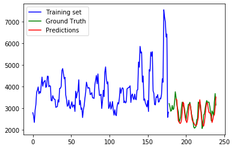

```python
plt.plot(X_train,label="Training set",color="blue")
plt.plot(range(178,178+len(X_test)),X_test, label="Ground Truth",color="green")
plt.plot(range(187,187+len(predictions)),
         [i for i in predictions],
         label="Predictions",color="red")
plt.legend()
plt.show()
```

As we can see, the model is able to predict the end of each scenes of the test set.

Now we can ask a new question :

Does the model/cinephile is able to predict the whole test set. I mean, does the model can make prediction on prediction iteratively and catch relevant information of the end of the film knowning ONLY the begining ?

```python
# Make predictions
predictions = model.predict(test_features)
for k in range(50):
    pred = scaler.inverse_transform(predictions)
    last = pred[-1]

    X_train.append(last)
    scaled = scaler.fit_transform(X_train)
    test_features = []
    for i in range(ws, len(X_train)):
        test_features.append(scaled[i - ws:i, 0])
    test_features = np.array(test_features)
    test_features = np.reshape(test_features, (test_features.shape[0], test_features.shape[1], 1))

    # Make predictions
    predictions = model.predict(test_features)

# Unscale the predictions
predictions = scaler.inverse_transform(predictions)
```

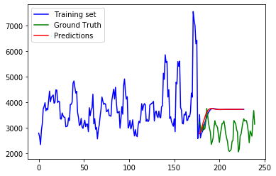

```python
plt.plot(X_train,label="Training set",color="blue")
plt.plot(range(178,178+len(X_test)),X_test, label="Ground Truth",color="green")
plt.plot(range(178,178+len(predictions[170:])),[i for i in predictions[170:]],label="Predictions",
        color='red')
plt.legend()
plt.show()
```

Let's talk in terms of sales. The model was able to predict the amplitude of the new increase after the huge peak. In a real life project, it can be a useful information to know when it comes to buying new stocks.

Additionnaly, we can see that the predictions are making a "plateau". This could be imputed to:

- The size of the dataset
- The quality of the kernel
- More generally, the stationarity of the time series

Thanks for having read my work !